# R Notebook

```r
#load packages
library(pacman)
p_load(boot, car, dplyr, ggplot2, Metrics, cowplot, tree,
       caret, randomForest, gbm, ElemStatLearn, magrittr, tidyverse, dplyr, haven, Hmisc, psych, janitor, corrplot, reshape, vcd, sfsmisc, DHARMa, e1071, MASS, fmsb)
```

```r
#load datasets
camdel <- read_spss("Cambridge_delinquency_with_caseid.sav")
conviction <- read_spss("conviction_data.sav")
str(conviction)
```

```
Classes ‘tbl_df’, ‘tbl’ and 'data.frame':   2877 obs. of  3 variables:
 $ icpsr_seq_id_number: num  1 2 3 4 5 6 7 8 9 10 ...
  ..- attr(*, "format.spss")= chr "F8.2"
 $ agecat             : chr  "convicted_10_13" "convicted_10_13" "convicted_10_13" "convicted_10_13" ...
  ..- attr(*, "format.spss")= chr "A21"
 $ convicted          : num  1 1 1 1 1 1 1 1 2 1 ...
  ..- attr(*, "format.spss")= chr "F8.2"
```

Question 1: Merge the two data files,select the variables and cases you need for the later analysis. Rename variables so that they are identifiable and usable

```r
#create and rename new data file with data in a wide format to make the merge file easier as there will common columns amongst the data set
conviction_wide <- spread(conviction, key=agecat, value=convicted)#moving from long to wide data format
colnames(conviction_wide)[1:8] <- c("v4", "v5", "v11", "v6", "v7", "v8", "v10", "v9")#renaming variables in conviction file to variable number according to code book
#adding data labels to conviction data
var.labels <- c(v4="ICPSR SEQ ID NUMBER", v5="CONVICTED 10-13", v11="CONVICTED 10-24", v6="CONVICTED 14-16", v7="CONVICTED 17-20", v8="CONVICTED 21-24",
v10="CONVICTED AS ADULT 17-24",v9="CONVICTED AS JUVENILE 10-16")
attr(conviction_wide, "variable.labels") <- var.labels
#joining data sets by v4 and assigning this to a new data frame
full_camdel <- camdel %>% left_join(conviction_wide)
```

```
Column `v4` has different attributes on LHS and RHS of join
```

Selecting important variables to analyse: According to Kazemian(2011), measures in infancy is not associated with neglect and delinquency while Krohn (2006) looks at predictors of offending where infancy measures are not as important as antisocial child behavior, impulsivity, low intelligence or attainment, family criminality, poverty and poor parental child-rearing behavior. This analysis will aim to model Krohn’s predictors on the data set. #variables of interest are: 4 ICPSR SEQUENTIAL IDENTIFICATION NUMBER 9 CONVICTED AS JUVENILE 10-16 10 CONVICTED AS ADULT 17-24 28 NUMBER OF JUVENILE CONVICTIONS 29 NUMBER OF ADULT CONVICTIONS 39 ADVENTUROUSNESS OF BOY 42 ACTING OUT 53 CONDUCT DISORDER OF BOY AGES 8 THROUGH 9 62 DISCIPLINE QUALITY OF FATHER 63 DISCIPLINE QUALITY OF MOTHER 108 OBEDIENCE OF BOY 117 OUTGOING OR WITHDRAWN BOY 119 PROGRESSIVE MATRICES IQ 132 RULES OF PARENTS 138 SOCIOECONOMIC STATUS OF FAMILY AGES 24 THROUGH 25 847 CURRENT EMPLOYMENT STATUS 858 LIVING CIRCUMSTANCES

```r
#These variables will look at the relationship between factors at age 8-9 vs life at 24-25.
camdel_selected <- dplyr::select(full_camdel, c("v4" ,"v9" ,"v10" ,"v28" ,"v29" ,"v39","v42" ,"v53" ,"v62" ,"v63" ,"v108","v117" ,"v119" ,"v132" ,"v138" ,"v847" ,"v858"))
var.labels <- c(v4="ICPSR SEQ ID NUMBER", v9="CONVICTED AS JUVENILE 10-16", v10="CONVICTED AS ADULT 17-24")
attr(camdel_selected, "variable.labels") <- var.labels #adding variable labels to see what each variable actually is
#renaming variables for easier understanding when doing analyses
camdel_selected %<>%
rename(c("v4"="SEQ_ID_NUMBER", "v9"="CONVICTED_AS_JUVENILE", "v10"="CONVICTED_AS_ADULT", "v28"="NO_JUVENILE_CONVICTIONS", "v29"="NO_ADULT_CONVICTIONS", "v39"="ADVENTUROUSNESS", "v42"="ACTING_OUT", "v53"="CONDUCT_DISORDER", "v62"="DISCIPLINE_FATHER", "v63"="DISCIPLINE_MOTHER", "v108"="OBEDIENCE", "v117"="OUTGOINGorWITHDRAWN", "v119"="IQ", "v132"="PARENT_RULES", "v138"="ses", "v847"="CURRENT_EMPLOYMENT", "v858"="CIRCUMSTANCES"))
```

Question 2: Explore the data set, bearing in mind that our key question concerns what the early life determinants of criminality are. What is worth exploring further?

```r
glimpse(camdel_selected)
```

```
Observations: 411
Variables: 17
$ SEQ_ID_NUMBER           <dbl> 1, 2, 3, 4, 5, 6, 7, 8, 9, 10, 11, 12, ...
$ CONVICTED_AS_JUVENILE   <dbl> 1, 1, 2, 2, 1, 1, 1, 1, 2, 1, 1, 1, 2, ...
$ CONVICTED_AS_ADULT      <dbl> 1, 1, 1, 2, 2, 1, 1, 1, 2, 2, 1, 2, 2, ...
$ NO_JUVENILE_CONVICTIONS <dbl+lbl> 1, 1, 2, 2, 1, 1, 1, 1, 2, 1, 1, 1,...
$ NO_ADULT_CONVICTIONS    <dbl+lbl> 1, 1, 1, 2, 3, 1, 1, 1, 2, 4, 1, 2,...
$ ADVENTUROUSNESS         <dbl+lbl> 2, 1, 2, 3, 2, 1, 2, 2, 2, 2, 2, NA...
$ ACTING_OUT              <dbl+lbl> 1, 1, 1, 1, 1, 1, 1, 1, 1, 1, 1, 1,...
$ CONDUCT_DISORDER        <dbl+lbl> 1, 1, 3, 1, 1, 1, 1, 1, 1, 2, 1, NA...
$ DISCIPLINE_FATHER       <dbl+lbl> 1, NA, 1, 3, 1, 1, 1, 1, 1, NA, 1, ...
$ DISCIPLINE_MOTHER       <dbl+lbl> 2, 1, 1, 3, 1, 1, 1, 1, 1, 1, 1, NA...
$ OBEDIENCE               <dbl+lbl> 2, 2, 2, 1, 2, 3, 2, 2, 3, 3, 1, NA...
$ OUTGOINGorWITHDRAWN     <dbl+lbl> 1, 2, 1, 1, 2, 2, 2, 2, 2, 1, 1, NA...
$ IQ                      <dbl+lbl> 2, 3, 3, 4, 4, 4, 4, 2, 4, 1, 1, 2,...
$ PARENT_RULES            <dbl+lbl> 2, 1, 1, 3, 2, 2, 2, 2, 2, 2, 2, NA...
$ ses                     <dbl+lbl> 3, 5, 3, 3, 3, 3, 3, 3, 6, 4, 3, 5,...
$ CURRENT_EMPLOYMENT      <dbl+lbl> NA, NA, NA, 1, NA, NA, NA, NA, NA, ...
$ CIRCUMSTANCES           <dbl+lbl> NA, NA, NA, 4, NA, NA, NA, NA, NA, ...
```

From a quick look at the data file, it seems like there are a few missing values that might be problematic later on. Narrowing the variables down has also made dealing with the variables more easily.

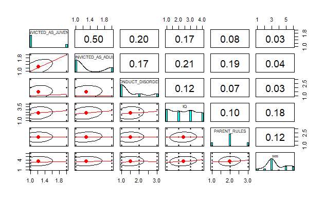

```r
#pairs.panels to look at basic correlations between childhood (8-9 years) and background variables.
camdel_selected %>%
  dplyr::select(2, 3, 8, 13, 14, 15) %>%
  pairs.panels()
```

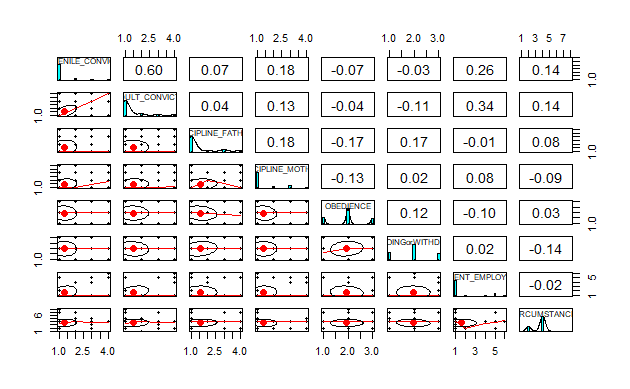

```r
camdel_selected %>%
  dplyr::select(4, 5, 9, 10, 11, 12, 16, 17) %>%
  pairs.panels()#breaking up variables as graph becomes unreadable with too many variables inputted
```

From the graphs above it seems like there is a moderate positive relationship between being convicted as a juvenile and then later on as an adult. It seems like the chosen background variables have a weak correlation with adult convictions. However, this be will be further explored in question 3.

```r
#looking at distribution of individual characteristics at ages 8-9
cor(camdel_selected, use="complete.obs", method="kendall")
```

```
                        SEQ_ID_NUMBER CONVICTED_AS_JUVENILE
SEQ_ID_NUMBER             1.000000000           -0.06151109
CONVICTED_AS_JUVENILE    -0.061511095            1.00000000
CONVICTED_AS_ADULT       -0.133519447            0.55761053
NO_JUVENILE_CONVICTIONS  -0.041720188            0.91825250
NO_ADULT_CONVICTIONS     -0.134829843            0.44819339
ADVENTUROUSNESS          -0.183837146            0.32873559
ACTING_OUT               -0.020766851            0.34937494
CONDUCT_DISORDER         -0.059741501            0.34157674
DISCIPLINE_FATHER        -0.079015841            0.30017299
DISCIPLINE_MOTHER         0.183735542            0.41089889
OBEDIENCE                -0.079382230           -0.06762522
OUTGOINGorWITHDRAWN       0.163692290           -0.19568230
IQ                       -0.012871880            0.19772179
PARENT_RULES             -0.240282652            0.02439328
ses                       0.012530457           -0.18549251
CURRENT_EMPLOYMENT       -0.009409755            0.04477363
CIRCUMSTANCES            -0.146437918            0.20230876
                        CONVICTED_AS_ADULT NO_JUVENILE_CONVICTIONS
SEQ_ID_NUMBER                 -0.133519447             -0.04172019
CONVICTED_AS_JUVENILE          0.557610532              0.91825250
CONVICTED_AS_ADULT             1.000000000              0.48383394
NO_JUVENILE_CONVICTIONS        0.483833936              1.00000000
NO_ADULT_CONVICTIONS           0.899652711              0.43037331
ADVENTUROUSNESS                0.390729605              0.30007081
ACTING_OUT                     0.260625009              0.34754894
CONDUCT_DISORDER               0.372841271              0.35846136
DISCIPLINE_FATHER              0.162523728              0.29520125
DISCIPLINE_MOTHER              0.190286653              0.36749712
OBEDIENCE                      0.008787496             -0.09355953
OUTGOINGorWITHDRAWN           -0.352208722             -0.18697032
IQ                             0.190316821              0.21592763
PARENT_RULES                   0.137545013              0.01359951
ses                           -0.002421125             -0.15207943
CURRENT_EMPLOYMENT             0.147875855              0.09707353
CIRCUMSTANCES                  0.142710738              0.17250120
                        NO_ADULT_CONVICTIONS ADVENTUROUSNESS  ACTING_OUT
SEQ_ID_NUMBER                    -0.13482984     -0.18383715 -0.02076685
CONVICTED_AS_JUVENILE             0.44819339      0.32873559  0.34937494
CONVICTED_AS_ADULT                0.89965271      0.39072960  0.26062501
```

[output cut: 71 more lines]

```
CONVICTED_AS_ADULT             0.147875855   0.142710738
NO_JUVENILE_CONVICTIONS        0.097073528   0.172501201
NO_ADULT_CONVICTIONS           0.214821902   0.129234774
ADVENTUROUSNESS                0.071628019   0.263543418
ACTING_OUT                     0.303521483  -0.047021346
CONDUCT_DISORDER               0.279480147   0.148023515
DISCIPLINE_FATHER              0.004535252   0.076407562
DISCIPLINE_MOTHER              0.057062488   0.003683368
OBEDIENCE                     -0.025379914   0.006837981
OUTGOINGorWITHDRAWN            0.072275024  -0.091078436
IQ                             0.157333141   0.143466894
PARENT_RULES                   0.228160679   0.120574511
ses                            0.107423446  -0.013344975
CURRENT_EMPLOYMENT             1.000000000  -0.123793988
CIRCUMSTANCES                 -0.123793988   1.000000000
```

From the correlations above, it can be seen that there is a moderate positive relationship between being convicted as a juvenile and then later on being convicted as an adult. Conduct disorder also seems to be correlated with boys acting out and their adventurousness. Therefore, for simplicity in question 3, conduct disorder will be used as a proxy for adventurousness and acting out.

Question 3: Model the occurrence and extent of criminality in our participants on the basis of early life events or factors. Interpret your model(s). Write a function to assess the predictive accuracy of your model(s), test it, and apply it to your data.

```r
#LDA model predicting whether boys were convicted as an adult based on a combination of their individual behaviours and family influences
camdel_model1 <- dplyr::select(camdel_selected, -c(16, 17 ))#removing adult variables that are not of interest
#splitting data into test and training set
set.seed(2)
camdel_traindata <- sample_frac(camdel_model1, 0.75)
camdel_testdata  <- dplyr::setdiff(camdel_model1, camdel_traindata)
```

[output not shown]

```r
#looling at descriptives of data
describe(camdel_traindata, na.rm=TRUE)
```

|  | vars | n | mean | sd | median | trimmed | mad | min | max | range | skew | kurtosis | se |
| --- | --- | --- | --- | --- | --- | --- | --- | --- | --- | --- | --- | --- | --- |
| SEQ_ID_NUMBER | 1 | 308 | 211.44 | 121.04 | 216.5 | 212.10 | 160.12 | 3 | 411 | 408 | -0.04 | -1.26 | 6.90 |
| CONVICTED_AS_JUVENILE | 2 | 308 | 1.19 | 0.39 | 1.0 | 1.11 | 0.00 | 1 | 2 | 1 | 1.59 | 0.52 | 0.02 |
| CONVICTED_AS_ADULT | 3 | 297 | 1.27 | 0.44 | 1.0 | 1.21 | 0.00 | 1 | 2 | 1 | 1.03 | -0.93 | 0.03 |
| NO_JUVENILE_CONVICTIONS | 4 | 308 | 1.31 | 0.74 | 1.0 | 1.11 | 0.00 | 1 | 4 | 3 | 2.48 | 5.32 | 0.04 |
| NO_ADULT_CONVICTIONS | 5 | 294 | 1.48 | 0.91 | 1.0 | 1.27 | 0.00 | 1 | 4 | 3 | 1.75 | 1.76 | 0.05 |
| ADVENTUROUSNESS | 6 | 283 | 2.03 | 0.59 | 2.0 | 2.04 | 0.00 | 1 | 3 | 2 | -0.01 | -0.16 | 0.04 |
| ACTING_OUT | 7 | 308 | 1.19 | 0.40 | 1.0 | 1.12 | 0.00 | 1 | 2 | 1 | 1.53 | 0.35 | 0.02 |
| CONDUCT_DISORDER | 8 | 273 | 1.51 | 0.77 | 1.0 | 1.39 | 0.00 | 1 | 3 | 2 | 1.09 | -0.46 | 0.05 |
| DISCIPLINE_FATHER | 9 | 274 | 1.60 | 1.02 | 1.0 | 1.38 | 0.00 | 1 | 4 | 3 | 1.40 | 0.44 | 0.06 |
| DISCIPLINE_MOTHER | 10 | 279 | 1.39 | 0.77 | 1.0 | 1.22 | 0.00 | 1 | 4 | 3 | 1.79 | 1.97 | 0.05 |

[output cut: 5 more lines]

```r
#Build the model1 on the training data set using convicted as an adult as the outcome
modeltrain <- glm(CONVICTED_AS_ADULT ~ CONVICTED_AS_JUVENILE +
                       NO_JUVENILE_CONVICTIONS + NO_ADULT_CONVICTIONS +
                       CONDUCT_DISORDER + DISCIPLINE_FATHER +
                       DISCIPLINE_MOTHER +  OBEDIENCE + OUTGOINGorWITHDRAWN +
                       IQ + ses, data = camdel_traindata)
summary(modeltrain)
```

```
Call:
glm(formula = CONVICTED_AS_ADULT ~ CONVICTED_AS_JUVENILE + NO_JUVENILE_CONVICTIONS +
    NO_ADULT_CONVICTIONS + CONDUCT_DISORDER + DISCIPLINE_FATHER +
    DISCIPLINE_MOTHER + OBEDIENCE + OUTGOINGorWITHDRAWN + IQ +
    ses, data = camdel_traindata)

Deviance Residuals:
     Min        1Q    Median        3Q       Max
-0.48487  -0.09308  -0.04582   0.01645   0.58697

Coefficients:
                          Estimate Std. Error t value Pr(>|t|)
(Intercept)              0.6891518  0.0891323   7.732 3.38e-13 ***
CONVICTED_AS_JUVENILE    0.1949813  0.0717888   2.716  0.00711 **
NO_JUVENILE_CONVICTIONS -0.1686904  0.0409802  -4.116 5.38e-05 ***
NO_ADULT_CONVICTIONS     0.4512734  0.0175779  25.673  < 2e-16 ***
CONDUCT_DISORDER        -0.0160986  0.0195646  -0.823  0.41146
DISCIPLINE_FATHER        0.0009877  0.0136272   0.072  0.94228
DISCIPLINE_MOTHER        0.0020603  0.0183711   0.112  0.91080
OBEDIENCE               -0.0179908  0.0213109  -0.844  0.39944
OUTGOINGorWITHDRAWN     -0.0322793  0.0197512  -1.634  0.10358
IQ                       0.0354332  0.0122076   2.903  0.00406 **
ses                     -0.0212977  0.0089967  -2.367  0.01876 *
---
Signif. codes:  0 ‘***’ 0.001 ‘**’ 0.01 ‘*’ 0.05 ‘.’ 0.1 ‘ ’ 1

(Dispersion parameter for gaussian family taken to be 0.03922258)

    Null deviance: 46.3933  on 238  degrees of freedom
Residual deviance:  8.9427  on 228  degrees of freedom
  (69 observations deleted due to missingness)
AIC: -83.011

Number of Fisher Scoring iterations: 2
```

M and SD of data seems relatively similar with no large variances.

```r
#creating model2 using number of adult convictions as the outcome being predicted
modeltrain2 <- glm(NO_ADULT_CONVICTIONS ~ CONVICTED_AS_ADULT +
                    CONVICTED_AS_JUVENILE +
                       NO_JUVENILE_CONVICTIONS + NO_ADULT_CONVICTIONS +
                       CONDUCT_DISORDER + DISCIPLINE_FATHER +
                       DISCIPLINE_MOTHER +  OBEDIENCE + OUTGOINGorWITHDRAWN +
                       IQ + ses, data = camdel_traindata)
```

```
the response appeared on the right-hand side and was droppedproblem with term 4 in model.matrix: no columns are assigned
```

```r
summary(modeltrain2)
```

```
Call:
glm(formula = NO_ADULT_CONVICTIONS ~ CONVICTED_AS_ADULT + CONVICTED_AS_JUVENILE +
    NO_JUVENILE_CONVICTIONS + NO_ADULT_CONVICTIONS + CONDUCT_DISORDER +
    DISCIPLINE_FATHER + DISCIPLINE_MOTHER + OBEDIENCE + OUTGOINGorWITHDRAWN +
    IQ + ses, data = camdel_traindata)

Deviance Residuals:
     Min        1Q    Median        3Q       Max
-1.17410  -0.08754   0.01559   0.08894   1.48408

Coefficients:
                          Estimate Std. Error t value Pr(>|t|)
(Intercept)             -1.0969702  0.1769363  -6.200 2.62e-09 ***
CONVICTED_AS_ADULT       1.6464073  0.0641305  25.673  < 2e-16 ***
CONVICTED_AS_JUVENILE   -0.3031343  0.1378680  -2.199   0.0289 *
NO_JUVENILE_CONVICTIONS  0.4508491  0.0754374   5.976 8.71e-09 ***
CONDUCT_DISORDER         0.0416650  0.0373234   1.116   0.2655
DISCIPLINE_FATHER       -0.0006613  0.0260291  -0.025   0.9798
DISCIPLINE_MOTHER        0.0036656  0.0350901   0.104   0.9169
OBEDIENCE                0.0329362  0.0407103   0.809   0.4193
OUTGOINGorWITHDRAWN      0.0415484  0.0378467   1.098   0.2734
IQ                      -0.0376663  0.0236129  -1.595   0.1121
ses                      0.0444224  0.0171437   2.591   0.0102 *
---
Signif. codes:  0 ‘***’ 0.001 ‘**’ 0.01 ‘*’ 0.05 ‘.’ 0.1 ‘ ’ 1

(Dispersion parameter for gaussian family taken to be 0.143098)

    Null deviance: 201.699  on 238  degrees of freedom
Residual deviance:  32.626  on 228  degrees of freedom
  (69 observations deleted due to missingness)
AIC: 226.32

Number of Fisher Scoring iterations: 2
```

The first model has a much lower AIC which means that adult convictions is better predicted by individual and family characteristics than number of convictions as an adult. This is similar to Krohn’s(2006) findings which state that the most important independent childhood predictors of offending could be grouped under the headings of antisocial child behavior, impulsivity, low intelligence or attainment, family criminality, poverty and poor parental child-rearing behavior. However, this model indicates that IQ, SES, conviction as a juvenile and number of convictions as a juvenile are significant predictors of adult conviction.

```r
#test for significance of model 1
1-pchisq(modeltrain$deviance,
         modeltrain$df.residual)
```

```
[1] 1
```

The training regression model is not significant which means that the model seems to fit the data

```r
#comparing the training to the test model using anova
testmodel <- glm(CONVICTED_AS_ADULT ~ CONVICTED_AS_JUVENILE +
                       NO_JUVENILE_CONVICTIONS + NO_ADULT_CONVICTIONS +
                       CONDUCT_DISORDER + DISCIPLINE_FATHER +
                       DISCIPLINE_MOTHER +  OBEDIENCE + OUTGOINGorWITHDRAWN +
                       IQ + ses, data = camdel_testdata)
summary(testmodel)
```

```
Call:
glm(formula = CONVICTED_AS_ADULT ~ CONVICTED_AS_JUVENILE + NO_JUVENILE_CONVICTIONS +
    NO_ADULT_CONVICTIONS + CONDUCT_DISORDER + DISCIPLINE_FATHER +
    DISCIPLINE_MOTHER + OBEDIENCE + OUTGOINGorWITHDRAWN + IQ +
    ses, data = camdel_testdata)

Deviance Residuals:
     Min        1Q    Median        3Q       Max
-0.55107  -0.11092  -0.04825   0.03988   0.52056

Coefficients:
                          Estimate Std. Error t value Pr(>|t|)
(Intercept)              0.2170941  0.1879115   1.155 0.251841
CONVICTED_AS_JUVENILE    0.3561060  0.1203628   2.959 0.004196 **
NO_JUVENILE_CONVICTIONS -0.2549882  0.0738684  -3.452 0.000942 ***
NO_ADULT_CONVICTIONS     0.4707995  0.0330491  14.245  < 2e-16 ***
CONDUCT_DISORDER         0.0817061  0.0398493   2.050 0.044021 *
DISCIPLINE_FATHER       -0.0158942  0.0278273  -0.571 0.569687
DISCIPLINE_MOTHER        0.0199054  0.0319839   0.622 0.535702
OBEDIENCE                0.1109127  0.0424796   2.611 0.011008 *
OUTGOINGorWITHDRAWN      0.0373446  0.0405893   0.920 0.360657
IQ                       0.0005499  0.0223317   0.025 0.980423
ses                     -0.0328496  0.0180473  -1.820 0.072944 .
---
Signif. codes:  0 ‘***’ 0.001 ‘**’ 0.01 ‘*’ 0.05 ‘.’ 0.1 ‘ ’ 1

(Dispersion parameter for gaussian family taken to be 0.04401854)

    Null deviance: 17.3780  on 81  degrees of freedom
Residual deviance:  3.1253  on 71  degrees of freedom
  (21 observations deleted due to missingness)
AIC: -11.203

Number of Fisher Scoring iterations: 2
```

```r
testmodel1 <- predict(testmodel, camdel_traindata, type = "response")
anova(modeltrain, testmodel1)
```

```
Analysis of Deviance Table

Model: gaussian, link: identity

Response: CONVICTED_AS_ADULT

Terms added sequentially (first to last)

                        Df Deviance Resid. Df Resid. Dev
NULL                                      238     46.393
CONVICTED_AS_JUVENILE    1   8.7021       237     37.691
NO_JUVENILE_CONVICTIONS  1   0.9995       236     36.692
NO_ADULT_CONVICTIONS     1  27.1309       235      9.561
CONDUCT_DISORDER         1   0.0008       234      9.560
DISCIPLINE_FATHER        1   0.0015       233      9.558
DISCIPLINE_MOTHER        1   0.0003       232      9.558
OBEDIENCE                1   0.0496       231      9.508
OUTGOINGorWITHDRAWN      1   0.1161       230      9.392
IQ                       1   0.2298       229      9.163
ses                      1   0.2198       228      8.943
```

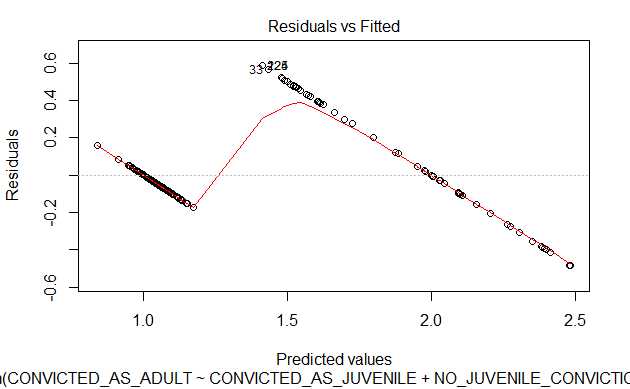

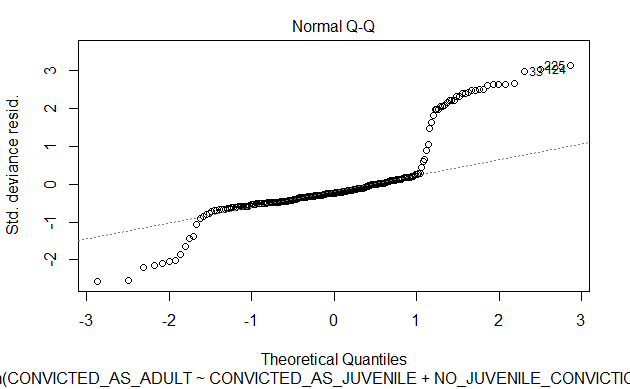

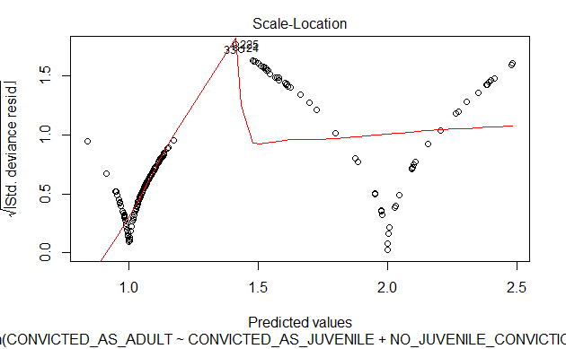

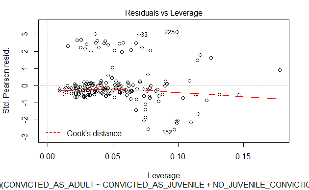

```r
#Diagnostics for logistic model
plot(modeltrain)
```

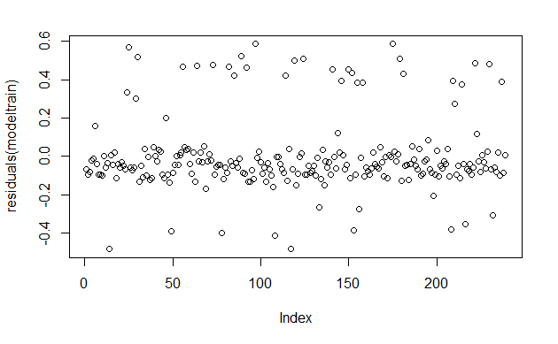

```r
plot(residuals(modeltrain))
```

```r
#looking at r squared value for model 1
NagelkerkeR2(modeltrain)
```

```
$`N`
[1] 239

$R2
[1] 0.8220356
```

The r squared value for model 1 indicates that 82% of the response variable variation is explained by a linear model which is good considering the fact that a few variables did not show any correlations to adult conviction.

```r
#creating a function to calculate MSE for modeltrain
mse = function (avec){
  (sum(avec$residuals^2))/(length(avec))}
mse(modeltrain)
```

```
[1] 0.2884757
```

```r
#running mse function for test model to look at different
mse(testmodel)
```

```
[1] 0.1008167
```